# Practical Machine Learning: Prediction Project

by Stephen Tay

## Background of this Project and Dataset

The goal of this project is to use data from wearable accelerometers to predict the manner in which six participants did the weight lifting exercise. The five manners of weight lifting which the data are to predict are as follows:

- **Class A**: Correct execution of a dumbbell biceps curl
- **Class B**: Throwing the elbows to the front
- **Class C**: Lifting the dumbbell only halfway
- **Class D**: Lowering the dumbbell only halfway
- **Class E**: Throwing the hips to the front

*Note: Classes B-E correspond to the common mistakes of doing dumbbell biceps curls. Details of this study and the dataset are available here: http://web.archive.org/web/20161224072740/http:/groupware.les.inf.puc-rio.br/har*

The source reference of this Weight Lifting Exercise dataset is as follows:

Velloso, E.; Bulling, A.; Gellersen, H.; Ugulino, W.; Fuks, H. **Qualitative Activity Recognition of Weight Lifting Exercises**. Proceedings of 4th International Conference in Cooperation with SIGCHI (Augmented Human ’13) . Stuttgart, Germany: ACM SIGCHI, 2013.

## Download File

```r
if(!file.exists("./data")){dir.create("./data")}
fileUrl <- "https://d396qusza40orc.cloudfront.net/predmachlearn/pml-training.csv"
download.file(fileUrl, destfile = "./data/dataset.csv", method = "curl")
```

## Read and Clean Data

While reading the .csv file, all cells which are empty, “NA” or erroneous are converted to become NA in the dataset. The dataset has 19622 obs with 160 variables.

```r
dataset <- read.csv("./data/dataset.csv", na.strings= c("", "NA", "#DIV/0!"))
str(dataset)
```

```
## 'data.frame':    19622 obs. of  160 variables:
##  $ X                       : int  1 2 3 4 5 6 7 8 9 10 ...
##  $ user_name               : Factor w/ 6 levels "adelmo","carlitos",..: 2 2 2 2 2 2 2 2 2 2 ...
##  $ raw_timestamp_part_1    : int  1323084231 1323084231 1323084231 1323084232 1323084232 1323084232 1323084232 1323084232 1323084232 1323084232 ...
##  $ raw_timestamp_part_2    : int  788290 808298 820366 120339 196328 304277 368296 440390 484323 484434 ...
##  $ cvtd_timestamp          : Factor w/ 20 levels "02/12/2011 13:32",..: 9 9 9 9 9 9 9 9 9 9 ...
##  $ new_window              : Factor w/ 2 levels "no","yes": 1 1 1 1 1 1 1 1 1 1 ...
##  $ num_window              : int  11 11 11 12 12 12 12 12 12 12 ...
##  $ roll_belt               : num  1.41 1.41 1.42 1.48 1.48 1.45 1.42 1.42 1.43 1.45 ...
##  $ pitch_belt              : num  8.07 8.07 8.07 8.05 8.07 8.06 8.09 8.13 8.16 8.17 ...
##  $ yaw_belt                : num  -94.4 -94.4 -94.4 -94.4 -94.4 -94.4 -94.4 -94.4 -94.4 -94.4 ...
##  $ total_accel_belt        : int  3 3 3 3 3 3 3 3 3 3 ...
##  $ kurtosis_roll_belt      : num  NA NA NA NA NA NA NA NA NA NA ...
##  $ kurtosis_picth_belt     : num  NA NA NA NA NA NA NA NA NA NA ...
##  $ kurtosis_yaw_belt       : logi  NA NA NA NA NA NA ...
```

[output cut: 86 more lines]

The proportion of missing data for each column is determined. Given that the proportion of missing data in some columns are very high (e.g. more than 90% of the column is NA), it would not be meaningful to impute these missing data.

```r
NAproportion <- colMeans(is.na(dataset))
print(NAproportion)
```

```
##                        X                user_name     raw_timestamp_part_1
##                0.0000000                0.0000000                0.0000000
##     raw_timestamp_part_2           cvtd_timestamp               new_window
##                0.0000000                0.0000000                0.0000000
##               num_window                roll_belt               pitch_belt
##                0.0000000                0.0000000                0.0000000
##                 yaw_belt         total_accel_belt       kurtosis_roll_belt
##                0.0000000                0.0000000                0.9798186
##      kurtosis_picth_belt        kurtosis_yaw_belt       skewness_roll_belt
##                0.9809398                1.0000000                0.9797676
##     skewness_roll_belt.1        skewness_yaw_belt            max_roll_belt
##                0.9809398                1.0000000                0.9793089
##           max_picth_belt             max_yaw_belt            min_roll_belt
##                0.9793089                0.9798186                0.9793089
##           min_pitch_belt             min_yaw_belt      amplitude_roll_belt
##                0.9793089                0.9798186                0.9793089
##     amplitude_pitch_belt       amplitude_yaw_belt     var_total_accel_belt
##                0.9793089                0.9798186                0.9793089
##            avg_roll_belt         stddev_roll_belt            var_roll_belt
##                0.9793089                0.9793089                0.9793089
##           avg_pitch_belt        stddev_pitch_belt           var_pitch_belt
##                0.9793089                0.9793089                0.9793089
##             avg_yaw_belt          stddev_yaw_belt             var_yaw_belt
##                0.9793089                0.9793089                0.9793089
##             gyros_belt_x             gyros_belt_y             gyros_belt_z
##                0.0000000                0.0000000                0.0000000
##             accel_belt_x             accel_belt_y             accel_belt_z
##                0.0000000                0.0000000                0.0000000
##            magnet_belt_x            magnet_belt_y            magnet_belt_z
##                0.0000000                0.0000000                0.0000000
##                 roll_arm                pitch_arm                  yaw_arm
##                0.0000000                0.0000000                0.0000000
##          total_accel_arm            var_accel_arm             avg_roll_arm
##                0.0000000                0.9793089                0.9793089
##          stddev_roll_arm             var_roll_arm            avg_pitch_arm
##                0.9793089                0.9793089                0.9793089
##         stddev_pitch_arm            var_pitch_arm              avg_yaw_arm
##                0.9793089                0.9793089                0.9793089
##           stddev_yaw_arm              var_yaw_arm              gyros_arm_x
##                0.9793089                0.9793089                0.0000000
```

[output cut: 53 more lines]

```
##                0.9835898                0.0000000                0.9793089
##         avg_roll_forearm      stddev_roll_forearm         var_roll_forearm
##                0.9793089                0.9793089                0.9793089
##        avg_pitch_forearm     stddev_pitch_forearm        var_pitch_forearm
##                0.9793089                0.9793089                0.9793089
##          avg_yaw_forearm       stddev_yaw_forearm          var_yaw_forearm
##                0.9793089                0.9793089                0.9793089
##          gyros_forearm_x          gyros_forearm_y          gyros_forearm_z
##                0.0000000                0.0000000                0.0000000
##          accel_forearm_x          accel_forearm_y          accel_forearm_z
##                0.0000000                0.0000000                0.0000000
##         magnet_forearm_x         magnet_forearm_y         magnet_forearm_z
##                0.0000000                0.0000000                0.0000000
##                   classe
##                0.0000000
```

To have a more accurate prediction, columns with more than 10% missing data are removed. As the first seven columns of the dataset are administrative (e.g. *username*, *timestamp*), these columns are removed as well. The cleaned dataset has 53 variables (including the outcome variable *“classe”*).

```r
df <- dataset[,NAproportion < 0.1]
df <- df[,-c(1:7)]
dim(df)
```

```
## [1] 19622    53
```

## Set Seed

```r
set.seed(2019)
```

## Create Training, Test and Validation Sets

The dataset is split into three datasets - training, test and validation sets. The validation set is meant to be a stand-by dataset in the event that I decide to use *model ensembling*, or if I need to choose between algorithms based on the test set which, in turn, requires additional validation.

There are 9619 obs in the training set, 4118 obs in the test set, and 5885 in the validation set.

```r
library(lattice)
library(ggplot2)
library(caret)
inValidate <- createDataPartition(y=df$classe, p=0.7, list=FALSE)
validation <- df[-inValidate,]
trainTestData <- df[inValidate,]

inTrain <- createDataPartition(y=trainTestData$classe, p=0.7, list = FALSE)
training <- trainTestData[inTrain,]
testing <- trainTestData[-inTrain,]

dim(training)
```

```
## [1] 9619   53
```

```r
dim(testing)
```

```
## [1] 4118   53
```

```r
dim(validation)
```

```
## [1] 5885   53
```

## Exploratory Data Analysis (EDA)

### EDA: Summary of Outcome Variable

The outcome variable has 5 categories, and this limits the ML algorithms that we can choose from (e.g. we can’t use linear or logistics regression).

```r
table(training$classe)
```

```
##
##    A    B    C    D    E
## 2735 1861 1678 1577 1768
```

### EDA: Correlation

The correlation plot shows that while several variables are highly correlated (i.e. dark coloured squares), majority of the variables are not (i.e. white/lightly coloured squares). As several variables are highly correlated, we can’t use Naive Bayes algorithm which assumes independence between features.

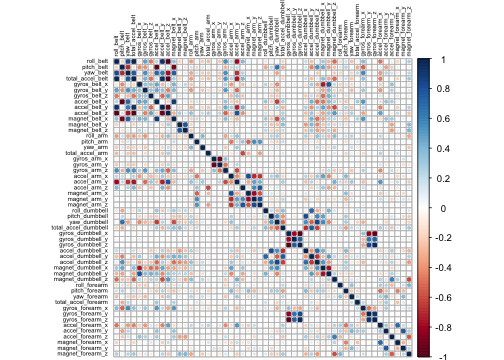

```r
library(corrplot)
correlationMatrix <- cor(training[,-53])
corrplot(correlationMatrix, tl.cex = 0.5, tl.col="black")
```

### EDA: Multinomial Logistics Regression

In order to have a quick overview of those features that are associated with the outcome variable, a multinomial logistics regression is conducted. Based on the average p-value of the features, we could see which variables that may be strong predictors of the outcome, and which may not. There are 26 features that are strongly associated with the outcome variable (i.e. average p-value is less than 0.05; note that the *Intercept* is not counted).

```r
library(nnet)
model <- multinom(classe ~., data= training)
```

```r
zvalues <- summary(model)$coefficients / summary(model)$standard.errors
pvalues <- pnorm(abs(zvalues), lower.tail=FALSE)*2
avePvalues <- colMeans(pvalues)
names(avePvalues[avePvalues<0.05])
```

```
##  [1] "(Intercept)"         "roll_belt"           "yaw_belt"
##  [4] "total_accel_belt"    "accel_belt_y"        "magnet_belt_x"
##  [7] "magnet_belt_y"       "magnet_belt_z"       "pitch_arm"
## [10] "total_accel_arm"     "accel_arm_x"         "accel_arm_y"
## [13] "accel_arm_z"         "magnet_arm_y"        "magnet_arm_z"
## [16] "roll_dumbbell"       "pitch_dumbbell"      "yaw_dumbbell"
## [19] "accel_dumbbell_x"    "accel_dumbbell_y"    "accel_dumbbell_z"
## [22] "magnet_dumbbell_x"   "magnet_dumbbell_y"   "magnet_dumbbell_z"
## [25] "pitch_forearm"       "total_accel_forearm" "magnet_forearm_z"
```

And there are 26 features that may be weak predictors of the outcome variable (i.e. average p-value is more than 0.05).

```r
names(avePvalues[avePvalues>0.05])
```

```
##  [1] "pitch_belt"           "gyros_belt_x"         "gyros_belt_y"
##  [4] "gyros_belt_z"         "accel_belt_x"         "accel_belt_z"
##  [7] "roll_arm"             "yaw_arm"              "gyros_arm_x"
## [10] "gyros_arm_y"          "gyros_arm_z"          "magnet_arm_x"
## [13] "total_accel_dumbbell" "gyros_dumbbell_x"     "gyros_dumbbell_y"
## [16] "gyros_dumbbell_z"     "roll_forearm"         "yaw_forearm"
## [19] "gyros_forearm_x"      "gyros_forearm_y"      "gyros_forearm_z"
## [22] "accel_forearm_x"      "accel_forearm_y"      "accel_forearm_z"
## [25] "magnet_forearm_x"     "magnet_forearm_y"
```

## Algorithm Selection Using Training Set

We will try out three algorithms on the training set:

- **Boosting with Trees**: given that out of 52 features, 26 features may be weak predictors of the outcome variable. Boosting could take lots of weak predictors, weight them and add them up to get a stronger predictor.
- **Random Forests**: since this algorithm tends to yield predictions of very high accuracy.
- **Linear Discriminant Analysis**: an algorithm that could potentially discriminate the classes of the outcome variable.

Should the in-sample accuracies of the above three algorithms are not high, I may consider *model ensembling* (i.e. combining algorithms) to yield better predictions.

### Algorithm 1 - Boosting with Trees

The in-sample accuracy of **Boosting** is 97.75%, and the in-sample error is 2.25%. This accuracy is considered very good:

```r
modgbm <- train(classe ~ ., data=training, method="gbm", verbose = FALSE)
```

```r
##In-sample Error for Boosting with Trees
confusionMatrixBoost <- confusionMatrix(training$classe, predict(modgbm, training))
print(confusionMatrixBoost)
```

```
## Confusion Matrix and Statistics
##
##           Reference
## Prediction    A    B    C    D    E
##          A 2717   15    0    2    1
##          B   36 1791   33    0    1
##          C    0   30 1632   13    3
##          D    2    2   36 1533    4
##          E    2   11    8   17 1730
##
## Overall Statistics
##
##                Accuracy : 0.9775
##                  95% CI : (0.9744, 0.9804)
##     No Information Rate : 0.2866
##     P-Value [Acc > NIR] : < 2.2e-16
##
##                   Kappa : 0.9716
##
##  Mcnemar's Test P-Value : NA
##
## Statistics by Class:
##
##                      Class: A Class: B Class: C Class: D Class: E
## Sensitivity            0.9855   0.9686   0.9549   0.9796   0.9948
## Specificity            0.9974   0.9910   0.9942   0.9945   0.9952
## Pos Pred Value         0.9934   0.9624   0.9726   0.9721   0.9785
## Neg Pred Value         0.9942   0.9925   0.9903   0.9960   0.9989
## Prevalence             0.2866   0.1922   0.1777   0.1627   0.1808
## Detection Rate         0.2825   0.1862   0.1697   0.1594   0.1799
## Detection Prevalence   0.2843   0.1935   0.1744   0.1639   0.1838
## Balanced Accuracy      0.9914   0.9798   0.9746   0.9870   0.9950
```

```r
paste("The in-sample error rate for Boosting is ", round((1- as.numeric(confusionMatrixBoost$overall[1]))*100, 2), "%", sep ="")
```

```
## [1] "The in-sample error rate for Boosting is 2.25%"
```

### Algorithm 2 - Random Forests

The in-sample accuracy of **Random Forests** is 100%, and the in-sample error is 0%. This accuracy, although very good, is expected given that this algorithm tends to overfit:

```r
modrf <- train(classe ~ ., data=training, method="rf")
```

```r
##In-sample Error for Random Forests
confusionMatrixRF <- confusionMatrix(training$classe, predict(modrf, training))
print(confusionMatrixRF)
```

```
## Confusion Matrix and Statistics
##
##           Reference
## Prediction    A    B    C    D    E
##          A 2735    0    0    0    0
##          B    0 1861    0    0    0
##          C    0    0 1678    0    0
##          D    0    0    0 1577    0
##          E    0    0    0    0 1768
##
## Overall Statistics
##
##                Accuracy : 1
##                  95% CI : (0.9996, 1)
##     No Information Rate : 0.2843
##     P-Value [Acc > NIR] : < 2.2e-16
##
##                   Kappa : 1
##
##  Mcnemar's Test P-Value : NA
##
## Statistics by Class:
##
##                      Class: A Class: B Class: C Class: D Class: E
## Sensitivity            1.0000   1.0000   1.0000   1.0000   1.0000
## Specificity            1.0000   1.0000   1.0000   1.0000   1.0000
## Pos Pred Value         1.0000   1.0000   1.0000   1.0000   1.0000
## Neg Pred Value         1.0000   1.0000   1.0000   1.0000   1.0000
## Prevalence             0.2843   0.1935   0.1744   0.1639   0.1838
## Detection Rate         0.2843   0.1935   0.1744   0.1639   0.1838
## Detection Prevalence   0.2843   0.1935   0.1744   0.1639   0.1838
## Balanced Accuracy      1.0000   1.0000   1.0000   1.0000   1.0000
```

```r
paste("The in-sample error rate for RF is ", round((1- as.numeric(confusionMatrixRF$overall[1]))*100, 2), "%", sep ="")
```

```
## [1] "The in-sample error rate for RF is 0%"
```

### Algorithm 3 - Linear Discriminant Analysis

The in-sample accuracy of **Linear Discriminant Analysis** is 71.2%, and the in-sample error is 28.8%. The accuracy of LDA is not as good as Boosting and RF:

```r
library(e1071)
modlda <- train(classe ~ ., data=training, method="lda")
```

```r
confusionMatrixLDA <- confusionMatrix(training$classe, predict(modlda, training))
print(confusionMatrixLDA)
```

```
## Confusion Matrix and Statistics
##
##           Reference
## Prediction    A    B    C    D    E
##          A 2236   57  228  209    5
##          B  292 1217  207   59   86
##          C  161  150 1118  204   45
##          D   91   72  167 1180   67
##          E   55  288  164  163 1098
##
## Overall Statistics
##
##                Accuracy : 0.712
##                  95% CI : (0.7029, 0.7211)
##     No Information Rate : 0.2947
##     P-Value [Acc > NIR] : < 2.2e-16
##
##                   Kappa : 0.6356
##
##  Mcnemar's Test P-Value : < 2.2e-16
##
## Statistics by Class:
##
##                      Class: A Class: B Class: C Class: D Class: E
## Sensitivity            0.7887   0.6822   0.5934   0.6501   0.8440
## Specificity            0.9264   0.9178   0.9276   0.9491   0.9195
## Pos Pred Value         0.8176   0.6539   0.6663   0.7483   0.6210
## Neg Pred Value         0.9130   0.9269   0.9035   0.9210   0.9741
## Prevalence             0.2947   0.1855   0.1959   0.1887   0.1353
## Detection Rate         0.2325   0.1265   0.1162   0.1227   0.1141
## Detection Prevalence   0.2843   0.1935   0.1744   0.1639   0.1838
## Balanced Accuracy      0.8576   0.8000   0.7605   0.7996   0.8817
```

```r
paste("The in-sample error rate for LDA is ", round((1- as.numeric(confusionMatrixLDA$overall[1]))*100, 2), "%", sep ="")
```

```
## [1] "The in-sample error rate for LDA is 28.8%"
```

## Cross-validation (Evaluate Boosting and RF on the Test Set)

Given the good performance on the training set, **Boosting** and **Random Forests** are selected for cross-validation on the test set. There is a possibility that Random Forests performs worse than Boosting on the test set because Random Forests tends to overfit. As the in-sample accuracies of Boosting and Random Forests are very high (97.75% and 100% respectively), there is no need to conduct *model ensembling*.

### Out-of-sample Error for Boosting with Trees

The out-of-sample accuracy of **Boosting** is 96.58%, and the out-of-sample error is 3.42%, which is still considered to be very good.

```r
testCMBoost <- confusionMatrix(testing$classe, predict(modgbm, testing))
print(testCMBoost)
```

```
## Confusion Matrix and Statistics
##
##           Reference
## Prediction    A    B    C    D    E
##          A 1163    6    2    0    0
##          B   31  743   23    0    0
##          C    0   21  687    9    1
##          D    2    0   19  651    3
##          E    1    9    7    7  733
##
## Overall Statistics
##
##                Accuracy : 0.9658
##                  95% CI : (0.9597, 0.9711)
##     No Information Rate : 0.2907
##     P-Value [Acc > NIR] : < 2.2e-16
##
##                   Kappa : 0.9567
##
##  Mcnemar's Test P-Value : NA
##
## Statistics by Class:
##
##                      Class: A Class: B Class: C Class: D Class: E
## Sensitivity            0.9716   0.9538   0.9309   0.9760   0.9946
## Specificity            0.9973   0.9838   0.9908   0.9930   0.9929
## Pos Pred Value         0.9932   0.9322   0.9568   0.9644   0.9683
## Neg Pred Value         0.9885   0.9892   0.9850   0.9954   0.9988
## Prevalence             0.2907   0.1892   0.1792   0.1620   0.1790
## Detection Rate         0.2824   0.1804   0.1668   0.1581   0.1780
## Detection Prevalence   0.2844   0.1935   0.1744   0.1639   0.1838
## Balanced Accuracy      0.9844   0.9688   0.9609   0.9845   0.9937
```

```r
testOSEboost <- round((1- as.numeric(testCMBoost$overall[1]))*100, 2)
paste("The out-of-sample error rate for Boosting is ", testOSEboost, "%", sep ="")
```

```
## [1] "The out-of-sample error rate for Boosting is 3.42%"
```

### Out-of-sample Error for Random Forests

The out-of-sample accuracy of **Random Forests** is 98.86%, and the out-of-sample error is 1.14%. The performance of Random Forests is still very good on the test set, and it is better than Boosting.

```r
testCMRF <- confusionMatrix(testing$classe, predict(modrf, testing))
print(testCMRF)
```

```
## Confusion Matrix and Statistics
##
##           Reference
## Prediction    A    B    C    D    E
##          A 1169    2    0    0    0
##          B   11  783    3    0    0
##          C    0   10  707    1    0
##          D    0    0   18  657    0
##          E    0    0    1    1  755
##
## Overall Statistics
##
##                Accuracy : 0.9886
##                  95% CI : (0.9849, 0.9916)
##     No Information Rate : 0.2865
##     P-Value [Acc > NIR] : < 2.2e-16
##
##                   Kappa : 0.9856
##
##  Mcnemar's Test P-Value : NA
##
## Statistics by Class:
##
##                      Class: A Class: B Class: C Class: D Class: E
## Sensitivity            0.9907   0.9849   0.9698   0.9970   1.0000
## Specificity            0.9993   0.9958   0.9968   0.9948   0.9994
## Pos Pred Value         0.9983   0.9824   0.9847   0.9733   0.9974
## Neg Pred Value         0.9963   0.9964   0.9935   0.9994   1.0000
## Prevalence             0.2865   0.1931   0.1770   0.1600   0.1833
## Detection Rate         0.2839   0.1901   0.1717   0.1595   0.1833
## Detection Prevalence   0.2844   0.1935   0.1744   0.1639   0.1838
## Balanced Accuracy      0.9950   0.9903   0.9833   0.9959   0.9997
```

```r
testOSErf <- round((1- as.numeric(testCMRF$overall[1]))*100, 2)
paste("The out-of-sample error rate for RF is ", testOSErf, "%", sep ="")
```

```
## [1] "The out-of-sample error rate for RF is 1.14%"
```

## Final Validation on the Selected Model (i.e Evaluate RF on the Validation Set)

Now, we will validate the **Random Forests** on the validation set. The accuracy of Random Forests is 98.74%, and the error is 1.26%.

```r
valCMRF <- confusionMatrix(validation$classe, predict(modrf, validation))
print(valCMRF)
```

```
## Confusion Matrix and Statistics
##
##           Reference
## Prediction    A    B    C    D    E
##          A 1671    2    0    1    0
##          B   15 1120    4    0    0
##          C    0   15 1011    0    0
##          D    0    0   33  930    1
##          E    0    0    1    2 1079
##
## Overall Statistics
##
##                Accuracy : 0.9874
##                  95% CI : (0.9842, 0.9901)
##     No Information Rate : 0.2865
##     P-Value [Acc > NIR] : < 2.2e-16
##
##                   Kappa : 0.9841
##
##  Mcnemar's Test P-Value : NA
##
## Statistics by Class:
##
##                      Class: A Class: B Class: C Class: D Class: E
## Sensitivity            0.9911   0.9850   0.9638   0.9968   0.9991
## Specificity            0.9993   0.9960   0.9969   0.9931   0.9994
## Pos Pred Value         0.9982   0.9833   0.9854   0.9647   0.9972
## Neg Pred Value         0.9964   0.9964   0.9922   0.9994   0.9998
## Prevalence             0.2865   0.1932   0.1782   0.1585   0.1835
## Detection Rate         0.2839   0.1903   0.1718   0.1580   0.1833
## Detection Prevalence   0.2845   0.1935   0.1743   0.1638   0.1839
## Balanced Accuracy      0.9952   0.9905   0.9803   0.9950   0.9992
```

```r
valOSErf <- round((1- as.numeric(valCMRF$overall[1]))*100, 2)
paste("The out-of-sample error rate for RF is ", valOSErf, "%", sep ="")
```

```
## [1] "The out-of-sample error rate for RF is 1.26%"
```

The average out-of-sample error rate of Random Forests on the test and validation sets is 1.20%. This is very good.

```r
averageOSE <- mean(c(testOSErf,valOSErf))
paste("The average out-of-sample error rate for RF is ", averageOSE, "%", sep ="")
```

```
## [1] "The average out-of-sample error rate for RF is 1.2%"
```